# Analysis of Wolf River pollution

This program reads data on the relationship sampling depth and two pollutant concentrations. Find more information in the [data dictionary](https://github.com/pmean/datasets/blob/master/wolf-river-pollution.yaml).

This program was written by Steve Simon on 2024-10-20 and is placed in the public domain.

## Load the tidyverse library

```r
library(broom)
library(tidyverse)
```

# — Part 1

## Read the data

```r
river <- read_tsv(
  file="../data/wolf-river-pollution.txt",
  col_names=TRUE,
  col_types="cnn")
names(river) <- tolower(names(river))
glimpse(river)
```

```
Rows: 30
Columns: 3
$ depth  <chr> "Surface", "Surface", "Surface", "Surface", "Surface", "Surface…
$ aldrin <dbl> 3.08, 3.58, 3.81, 4.31, 4.35, 4.40, 3.67, 5.17, 5.17, 4.35, 5.1…
$ hcb    <dbl> 3.74, 4.61, 4.00, 4.67, 4.87, 5.12, 4.52, 5.29, 5.74, 5.48, 6.0…
```

## Draw boxplots

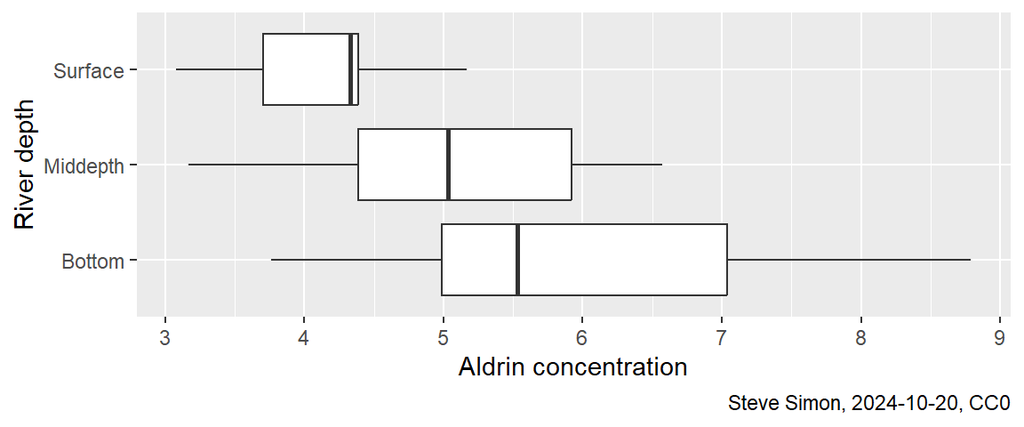

```r
river |>
  ggplot() +
  aes(aldrin, depth) +
  geom_boxplot() +
  labs(
    x="Aldrin concentration",
    y="River depth",
    caption="Steve Simon, 2024-10-20, CC0")
```

#### Interpretation of the output

The deeper you sample, the higher the concentration of Aldrin. The variation also increases as you go deeper. There are some minor deviations from normality, but nothing too serious.

## Descriptive statistics

```r
river |>
  group_by(depth) |>
  summarize(
    aldrin_mn=mean(aldrin),
    aldrin_sd=sd(aldrin),
    n=n())
```

```
# A tibble: 3 × 4
  depth    aldrin_mn aldrin_sd     n
  <chr>        <dbl>     <dbl> <int>
1 Bottom        6.02     1.58     10
2 Middepth      5.02     1.10     10
3 Surface       4.19     0.671    10
```

#### Interpretation of the output

The bottom samples have the highest average concentration and the highest amount of variability.

## Analysis of variance table

```r
m1 <- aov(aldrin ~ depth, data=river)
tidy(m1)
```

```
# A tibble: 2 × 6
  term         df sumsq meansq statistic  p.value
  <chr>     <dbl> <dbl>  <dbl>     <dbl>    <dbl>
1 depth         2  16.8   8.42      6.05  0.00674
2 Residuals    27  37.5   1.39     NA    NA
```

#### Interpretation of the output

The F-ratio is large and the p-value is less than alpha. You should reject the null hypothesis and conclude that at least two means differ from one another.

## Pairwise tests

```r
TukeyHSD(m1)
```

```
  Tukey multiple comparisons of means
    95% family-wise confidence level

Fit: aov(formula = aldrin ~ depth, data = river)

$depth
                   diff       lwr        upr     p adj
Middepth-Bottom  -1.002 -2.309584  0.3055842 0.1580741
Surface-Bottom   -1.832 -3.139584 -0.5244158 0.0048136
Surface-Middepth -0.830 -2.137584  0.4775842 0.2739689
```

#### Interpretation of the output

There is a statistically significant difference in average concentration of Aldrin between the surface measurements and the bottom measurements. The confidence interval, however, is very wide, indicating a large amount of sampling error.

Although the average middepth measurements are larger than the surface measurements and smaller than the bottom measurements, the difference of about 0.8 to 1.0 units is not statistically significant.

# — Part 2

## Sample size calculation scenario

You want to replicate this study at a different site and want a lot more precision and power. If the amount of sampling error (mean squared within) is similar, and the populations means are very close (4.8 for the surface, 5.0 for the middepth, and 5.2 for the bottom), what sample size would you need to achieve 90% power with an alpha level of 0.05?

## Sample size calculation, R code

```r
v <- var(c(4.8, 5.0, 5.2))
power.anova.test(
    groups=3,
    n=NULL,
    between.var=v,
    within.var=1.39,
    sig.level=0.05,
    power=0.90)
```

```
     Balanced one-way analysis of variance power calculation

         groups = 3
              n = 220.8641
    between.var = 0.04
     within.var = 1.39
      sig.level = 0.05
          power = 0.9

NOTE: n is number in each group
```

#### Interpretation of the output

A sample size of 221 measurements per depth level would provide 90% power for detecting a difference between means of 4.8, 5.0, and 5.2 in aldrin concentration. This assumes that the variation within groups is similar to the previous study (1.39) and an alpha level of 0.05.

There is no way in heaven or earth that you can afford to make 221 measurements at each depth. So give up the idea that you can detect changes in means across such a narrow range. Suppose that you want to be able to detect differences among means that are 4.5, 5.0, and 5.5. If you could live with that and if everything remains the same, what sample size would you need?

## Recalculate sample size, R code

```r
v <- var(c(4.5, 5.0, 5.5))
power.anova.test(
    groups=3,
    n=NULL,
    between.var=v,
    within.var=1.39,
    sig.level=0.05,
    power=0.90)
```

```
     Balanced one-way analysis of variance power calculation

         groups = 3
              n = 36.19717
    between.var = 0.25
     within.var = 1.39
      sig.level = 0.05
          power = 0.9

NOTE: n is number in each group
```

#### Interpretation of the output

Much better! A sample size of 37 measurements per depth level would provide 90% power for detecting a difference between means of 4.5, 5.0, and 5.5 in aldrin concentration. This assumes that the variation within groups is similar to the previous study (1.39) and an alpha level of 0.05.